# HW2

# Introduction

In this homework, I will try to estimate the April 2021 value of ‘Consumer Price Index for Alcoholic Beverages and Tobacco’ in Turkey by constructing a time series regression model. Relevant predictors will be examined step by step and, and I will try to construct a model having residuals with zero mean and constant variance and also I will try to minimize autocorrelation by necessary manipulations.

# Data Preperation

Necessary Libraries

```r
library(ggplot2)
library(data.table)
library(readxl)
library(lubridate)
library(forecast)
```

Data for CPI, USD, and EUR are added to the data from 2008-10 to 2021-3

```r
Data <- read_excel("/Users/tolgaerdogan/Documents/GitHub/spring21-TolgaErdogann/Data/EVDS.xlsx")
Data <- as.data.table(Data)
Data$Date <- as.Date(Data$Date)
head(Data)
```

```
##          Date CPIAlc      USD      EUR    CPI
## 1: 2008-10-01 192.66 1.480000 1.962670 159.77
## 2: 2008-11-01 192.61 1.595505 2.021440 161.10
## 3: 2008-12-01 192.61 1.546226 2.086511 160.44
## 4: 2009-01-01 192.63 1.596729 2.114905 160.90
## 5: 2009-02-01 192.82 1.660335 2.115620 160.35
## 6: 2009-03-01 206.12 1.712764 2.218718 162.12
```

# Data Analysis and Visualization

## Historical Alcoholic Beverages and Tobacco CPI Data Analysis

Time series for Alcoholic Beverages and Tobacco CPI is plotted

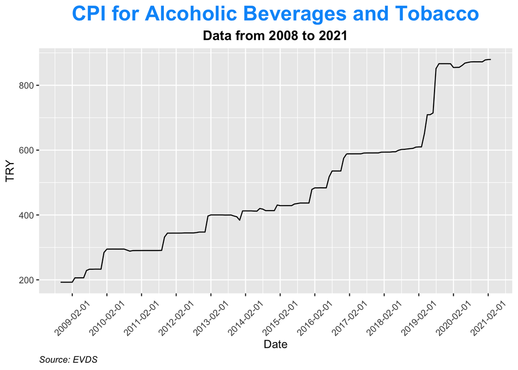

```r
ggplot(Data ,aes(x=Date,y=CPIAlc)) + geom_line() +
  labs(title = "CPI for Alcoholic Beverages and Tobacco",
       x = "Date",
       y = "TRY",
       subtitle = "Data from 2008 to 2021",
       caption = "Source: EVDS"
  ) +
  theme(axis.text.x = element_text(angle = 45, vjust = 0.5, hjust=0.5),plot.title = element_text(color = "#0099f9", size = 20, face = "bold", hjust = 0.5),
        plot.subtitle = element_text(size = 13, face = "bold", hjust = 0.5),
        plot.caption = element_text(face = "italic", hjust = 0))+
  scale_x_date(date_breaks = "12 months") +
  theme(axis.text.x = element_text(angle = 45, vjust = 0.5, hjust=0.5))
```

Since the variance doesn’t seem constant through time, I took the logarithm of CPI to linearize

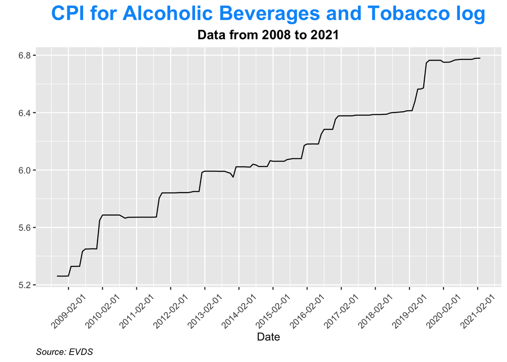

```r
Data$CPIAlc <- log(Data$CPIAlc)
ggplot(Data ,aes(x=Date,y=CPIAlc)) + geom_line()+
  labs(title = "CPI for Alcoholic Beverages and Tobacco log",
       x = "Date",
       y = "",
       subtitle = "Data from 2008 to 2021",
       caption = "Source: EVDS"
  ) +
  theme(axis.text.x = element_text(angle = 45, vjust = 0.5, hjust=0.5),plot.title = element_text(color = "#0099f9", size = 20, face = "bold", hjust = 0.5),
        plot.subtitle = element_text(size = 13, face = "bold", hjust = 0.5),
        plot.caption = element_text(face = "italic", hjust = 0))+
  scale_x_date(date_breaks = "12 months") +
  theme(axis.text.x = element_text(angle = 45, vjust = 0.5, hjust=0.5))
```

# Regression Analysis

## Trend Analysis

Since CPI increases with time as seen in graph, at first trend component is chosen as predictor

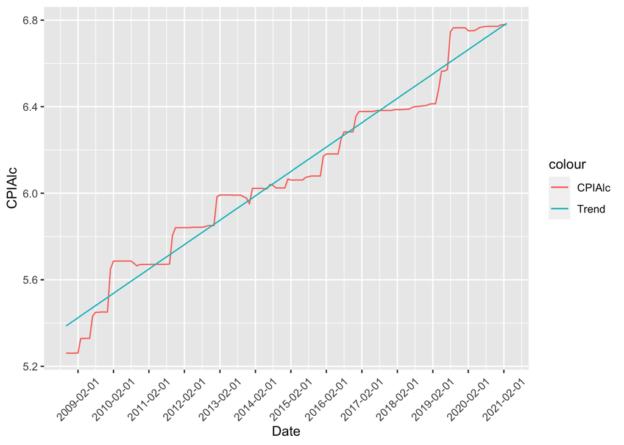

```r
Data[,trend:=1:.N]
ts_reg=lm(CPIAlc~trend,Data)
Data[,trend_constant:=predict(ts_reg,Data)]

ggplot(Data ,aes(x=Date)) +
  geom_line(aes(y=CPIAlc,color='CPIAlc')) +
  geom_line(aes(y=trend_constant,color='Trend'))+
  scale_x_date(date_breaks = "12 months") +
  theme(axis.text.x = element_text(angle = 45, vjust = 0.5, hjust=0.5))
```

```r
fit <- lm(CPIAlc~trend_constant, data = Data)
summary(fit)
```

```
##
## Call:
## lm(formula = CPIAlc ~ trend_constant, data = Data)
##
## Residuals:
##      Min       1Q   Median       3Q      Max
## -0.16241 -0.05105  0.00306  0.05239  0.14940
##
## Coefficients:
##                  Estimate Std. Error t value Pr(>|t|)
## (Intercept)    -9.282e-15  9.361e-02    0.00        1
## trend_constant  1.000e+00  1.535e-02   65.16   <2e-16 ***
## ---
## Signif. codes:  0 '***' 0.001 '**' 0.01 '*' 0.05 '.' 0.1 ' ' 1
##
## Residual standard error: 0.07641 on 148 degrees of freedom
## Multiple R-squared:  0.9663, Adjusted R-squared:  0.9661
## F-statistic:  4246 on 1 and 148 DF,  p-value: < 2.2e-16
```

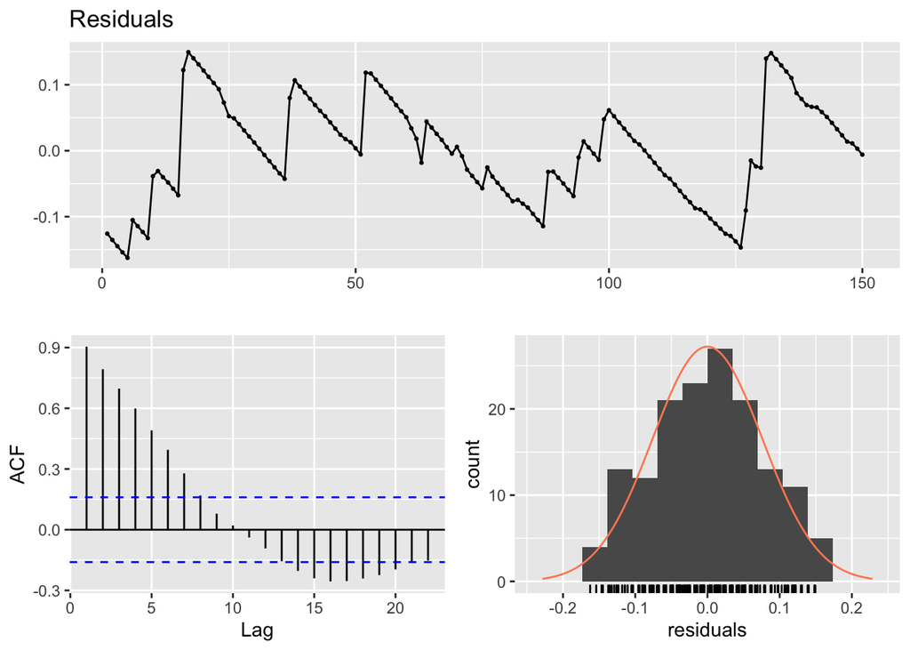

```
##
##  Breusch-Godfrey test for serial correlation of order up to 10
##
## data:  Residuals
## LM test = 125.12, df = 10, p-value < 2.2e-16
```

```r
checkresiduals(fit)
```

If we look at the results, adjusted r-square value and p-value seem successful however to ensure the assumptions made earlier we need to lover autocorrelation with adding new predictors to data

## Predictors

I added CPI and EUR values as predictors. If the price of basket increases we expect an increase in alcohol and tobacco prices as well. And also since Turkey imports alcohol mainly from Europe, it seems beneficial to add EUR exchange rates in model.

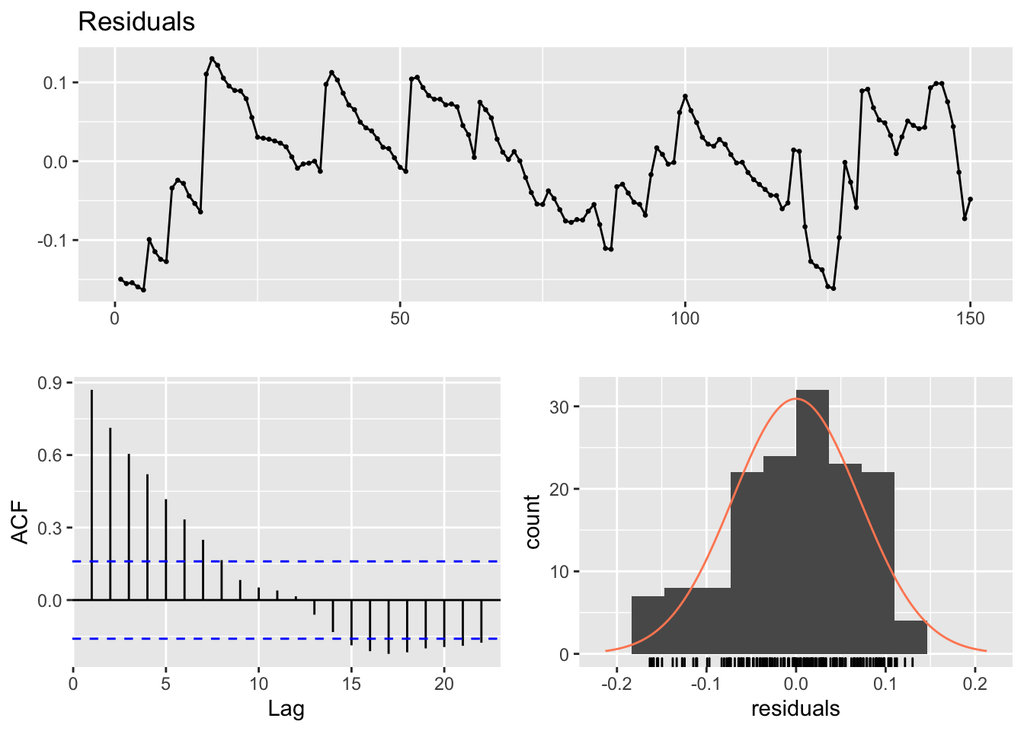

```
##
##  Breusch-Godfrey test for serial correlation of order up to 10
##
## data:  Residuals
## LM test = 117.67, df = 10, p-value < 2.2e-16
```

```r
fit <- lm(CPIAlc~trend_constant+CPI+EUR, data = Data)
checkresiduals(fit)
```

```r
summary(fit)
```

```
##
## Call:
## lm(formula = CPIAlc ~ trend_constant + CPI + EUR, data = Data)
##
## Residuals:
##       Min        1Q    Median        3Q       Max
## -0.163334 -0.047969  0.006974  0.051968  0.130066
##
## Coefficients:
##                  Estimate Std. Error t value Pr(>|t|)
## (Intercept)     1.3443477  0.3351183   4.012 9.60e-05 ***
## trend_constant  0.7000328  0.0716200   9.774  < 2e-16 ***
## CPI             0.0029336  0.0006251   4.693 6.14e-06 ***
## EUR            -0.0882762  0.0197031  -4.480 1.49e-05 ***
## ---
## Signif. codes:  0 '***' 0.001 '**' 0.01 '*' 0.05 '.' 0.1 ' ' 1
##
## Residual standard error: 0.07171 on 146 degrees of freedom
## Multiple R-squared:  0.9707, Adjusted R-squared:  0.9701
## F-statistic:  1614 on 3 and 146 DF,  p-value: < 2.2e-16
```

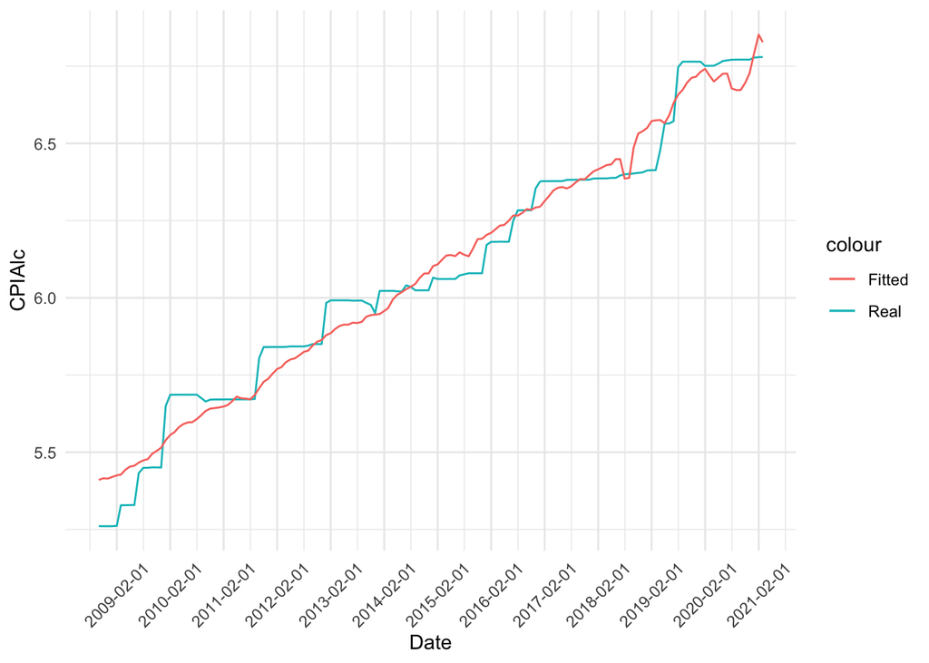

```r
Data[,regline:=predict(fit,Data)]
ggplot(Data ,aes(x=Date)) +
  geom_line(aes(y=CPIAlc, color='Real')) +
  geom_line(aes(y=regline,color='Fitted'))+
  theme_minimal()+
  scale_x_date(date_breaks = "12 months") +
  theme(axis.text.x = element_text(angle = 45, vjust = 0.5, hjust=0.5))
```

After we add the predictors, residual standard error and autocorrelation have decreased, however we couldn’t catch the lags seen on data. To improve our model we need to add lag information to the model.

## Adding appropriate lag to the model

I added lag1, lag3, lag6 and examined their correlation with residuals.

```r
Data[, residuals:=residuals(fit)]
Data[, lag1:=shift(residuals(fit),1)]
Data[, lag3:=shift(residuals(fit),3)]
Data[, lag6:=shift(residuals(fit),6)]
summary((lm(CPIAlc~trend_constant+CPI+EUR+lag6, data = Data)))
```

```
##
## Call:
## lm(formula = CPIAlc ~ trend_constant + CPI + EUR + lag6, data = Data)
##
## Residuals:
##       Min        1Q    Median        3Q       Max
## -0.164279 -0.034790 -0.004924  0.038019  0.145940
##
## Coefficients:
##                  Estimate Std. Error t value Pr(>|t|)
## (Intercept)     1.9891450  0.2916486   6.820 2.56e-10 ***
## trend_constant  0.5772219  0.0617245   9.352  < 2e-16 ***
## CPI             0.0033405  0.0005224   6.395 2.28e-09 ***
## EUR            -0.0889991  0.0164073  -5.424 2.51e-07 ***
## lag6            0.3477413  0.0699345   4.972 1.92e-06 ***
## ---
## Signif. codes:  0 '***' 0.001 '**' 0.01 '*' 0.05 '.' 0.1 ' ' 1
##
## Residual standard error: 0.05952 on 139 degrees of freedom
##   (6 observations deleted due to missingness)
## Multiple R-squared:  0.9771, Adjusted R-squared:  0.9764
## F-statistic:  1483 on 4 and 139 DF,  p-value: < 2.2e-16
```

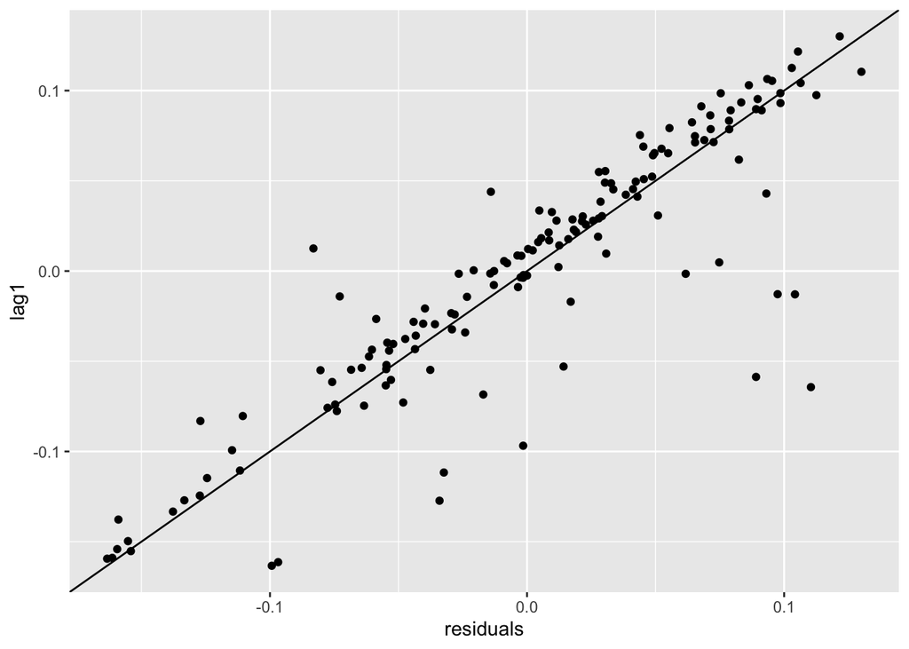

```r
ggplot(Data, aes(x=residuals, y= lag1))+
  geom_point()+
  geom_abline(slope=1, intercept = 0)
```

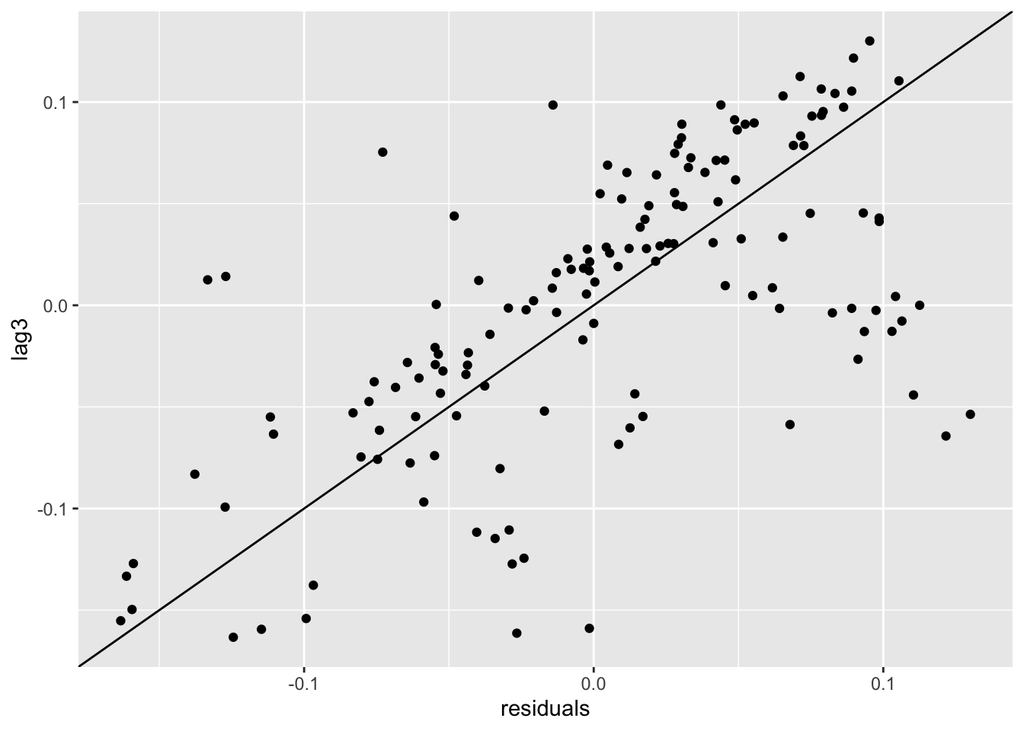

```r
ggplot(Data, aes(x=residuals, y= lag3))+
  geom_point()+
  geom_abline(slope=1, intercept = 0)
```

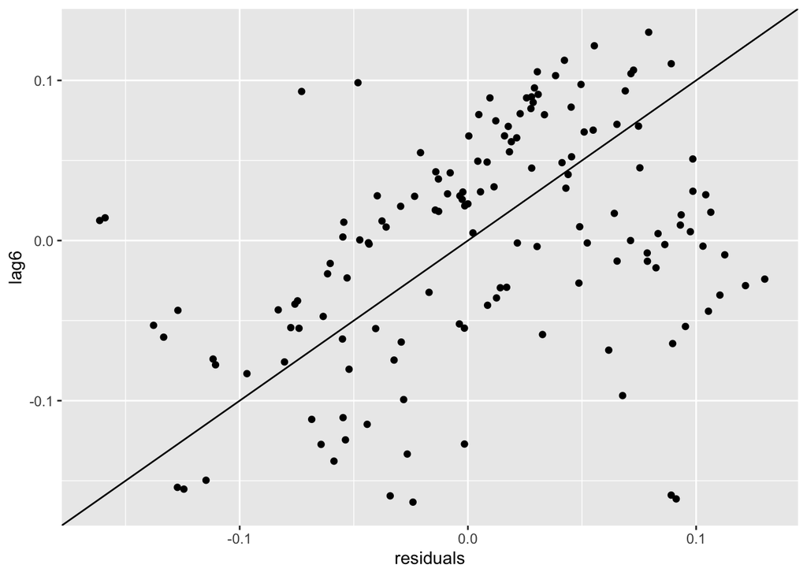

```r
ggplot(Data, aes(x=residuals, y= lag6))+
  geom_point()+
  geom_abline(slope=1, intercept = 0)
```

When we compare the lag options. Lag1 is the most appropriate one to add to the model

## Model Analysis

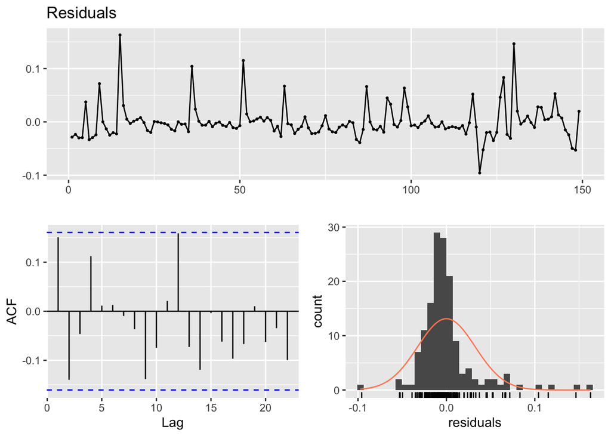

```
##
##  Breusch-Godfrey test for serial correlation of order up to 10
##
## data:  Residuals
## LM test = 13.047, df = 10, p-value = 0.2211
```

```r
fit <- lm(CPIAlc~trend_constant+CPI+EUR+lag1, data = Data)
checkresiduals(fit)
```

```r
summary(fit)
```

```
##
## Call:
## lm(formula = CPIAlc ~ trend_constant + CPI + EUR + lag1, data = Data)
##
## Residuals:
##       Min        1Q    Median        3Q       Max
## -0.095793 -0.015228 -0.005794  0.004103  0.163022
##
## Coefficients:
##                  Estimate Std. Error t value Pr(>|t|)
## (Intercept)     1.2915573  0.1561399   8.272 8.05e-14 ***
## trend_constant  0.7147070  0.0333139  21.454  < 2e-16 ***
## CPI             0.0026918  0.0002889   9.319  < 2e-16 ***
## EUR            -0.0799727  0.0090828  -8.805 3.77e-15 ***
## lag1            0.8743193  0.0381966  22.890  < 2e-16 ***
## ---
## Signif. codes:  0 '***' 0.001 '**' 0.01 '*' 0.05 '.' 0.1 ' ' 1
##
## Residual standard error: 0.033 on 144 degrees of freedom
##   (1 observation deleted due to missingness)
## Multiple R-squared:  0.9937, Adjusted R-squared:  0.9935
## F-statistic:  5696 on 4 and 144 DF,  p-value: < 2.2e-16
```

Adding lag1 has significantly lowered the autocorrelation

## Visualization of the model

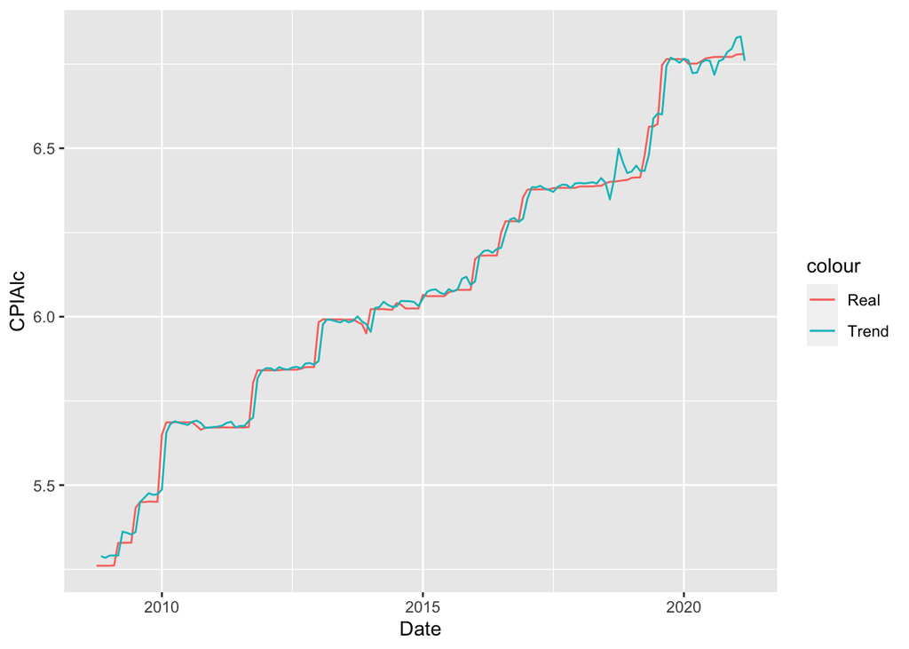

```r
Data[,regline:=predict(fit,Data)]
ggplot(Data ,aes(x=Date)) +
  geom_line(aes(y=CPIAlc, color='Real')) +
  geom_line(aes(y=regline,color='Trend'))
```

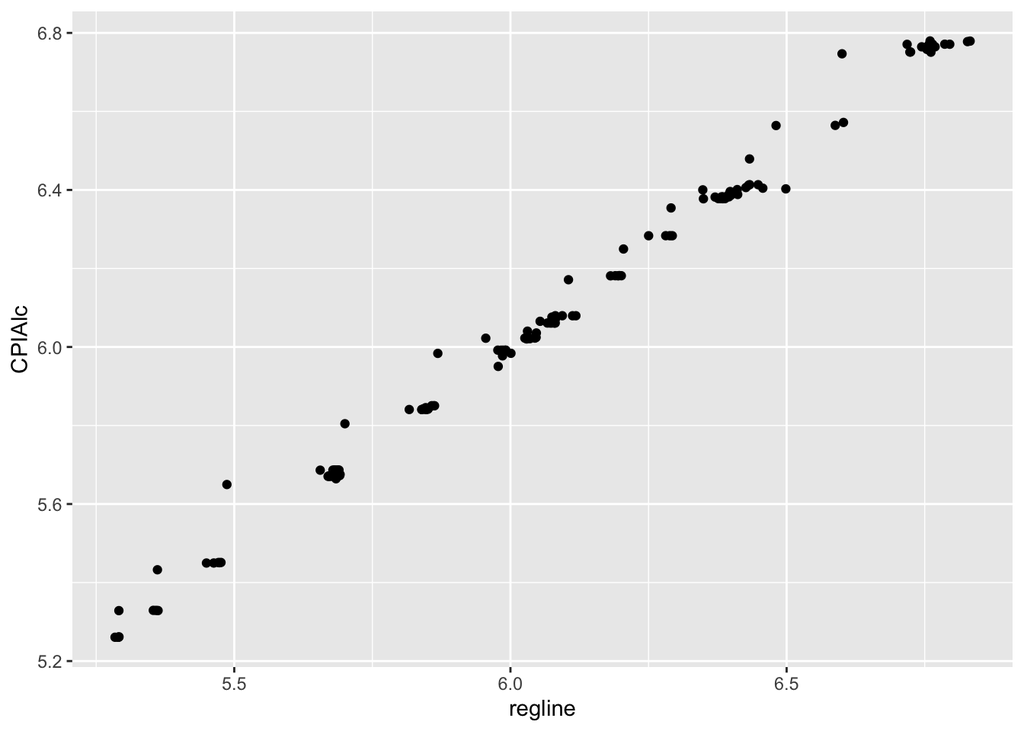

```r
ggplot(Data, aes(x=regline, y=CPIAlc))+
  geom_point()
```

# Forecast

At first I predicted the values of CPI and EUR for 2021-4 then I added those values to the model and predicted the value of CPI for Alcoholic Beverages and Tobacco for 2021-04.

```r
Data=rbind(Data, data.table(Date = as.Date("2021-04-01")),fill=T )
Data[,trend:=1:.N]
predict(Data$EUR)
```

```
##     Point Forecast    Lo 80     Hi 80    Lo 95     Hi 95
## 151       9.207696 8.794227  9.621164 8.575350  9.840041
## 152       9.324104 8.704349  9.943858 8.376271 10.271936
## 153       9.440511 8.637820 10.243203 8.212900 10.668122
## 154       9.556919 8.578857 10.534982 8.061102 11.052737
## 155       9.673327 8.521762 10.824892 7.912160 11.434494
## 156       9.789735 8.463812 11.115657 7.761911 11.817558
## 157       9.906142 8.403503 11.408782 7.608053 12.204232
## 158      10.022550 8.339924 11.705176 7.449196 12.595904
## 159      10.138958 8.272491 12.005424 7.284444 12.993472
## 160      10.255366 8.200810 12.309922 7.113193 13.397538
```

```r
predict(Data$CPI)
```

```
##     Point Forecast    Lo 80    Hi 80    Lo 95    Hi 95
## 151       529.1267 522.7853 535.4681 519.4284 538.8250
## 152       534.7234 525.2744 544.1724 520.2724 549.1744
## 153       540.3201 528.1493 552.4909 521.7065 558.9337
## 154       545.9168 531.1631 560.6705 523.3530 568.4806
## 155       551.5135 534.2261 568.8009 525.0747 577.9523
## 156       557.1102 537.2951 576.9254 526.8055 587.4149
## 157       562.7069 540.3461 585.0677 528.5090 596.9048
## 158       568.3036 543.3647 593.2426 530.1628 606.4444
## 159       573.9003 546.3415 601.4592 531.7527 616.0479
## 160       579.4970 549.2702 609.7238 533.2692 625.7249
```

```r
predict(Data$lag1)
```

```
##     Point Forecast      Lo 80        Hi 80      Lo 95        Hi 95
## 151    -0.07285283 -0.1164489 -0.029256799 -0.1395272 -0.006178456
## 152    -0.07285283 -0.1345038 -0.011201816 -0.1671399  0.021434257
## 153    -0.07285283 -0.1483583  0.002652673 -0.1883285  0.042622870
## 154    -0.07285283 -0.1600383  0.014332688 -0.2061916  0.060485911
## 155    -0.07285283 -0.1703287  0.024623054 -0.2219293  0.076223668
## 156    -0.07285283 -0.1796319  0.033926294 -0.2361574  0.090451746
## 157    -0.07285283 -0.1881872  0.042481531 -0.2492415  0.103535852
## 158    -0.07285283 -0.1961502  0.050444568 -0.2614199  0.115714266
## 159    -0.07285283 -0.2036293  0.057923627 -0.2728582  0.127152500
## 160    -0.07285283 -0.2107032  0.064997506 -0.2836767  0.137971064
```

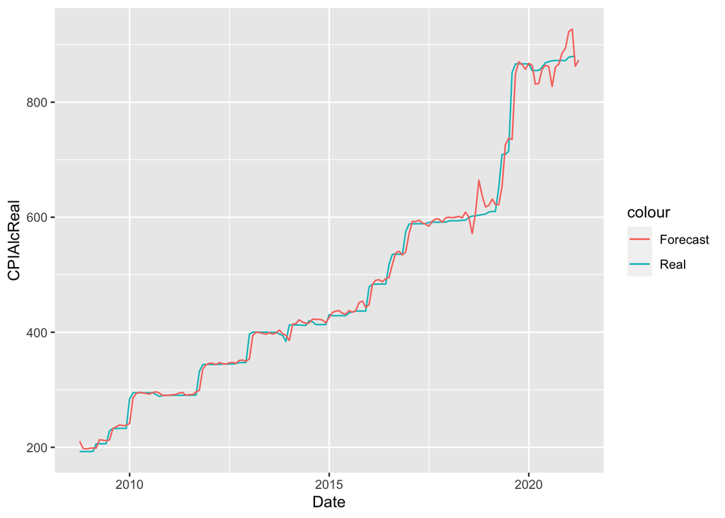

```r
Data[is.na(CPI)==T, CPI:= 529.12]
Data[is.na(EUR)==T, EUR:= 9.208]
Data[is.na(lag1)==T, lag1:= "-0.07285283"]
ts_reg=lm(CPIAlc~trend,Data)
Data[,trend_constant:=predict(ts_reg,Data)]


Data[is.na(regline)==T, regline:=predict(fit, Data[is.na(regline)])]
Data[,CPIAlcReal:=exp(CPIAlc)]
Data[,CPIAlcPred:=exp(regline)]

ggplot(Data ,aes(x=Date)) +
  geom_line(aes(y=CPIAlcReal, color='Real')) +
  geom_line(aes(y=CPIAlcPred,color='Forecast'))
```

```r
Data$CPIAlcPred[151]
```

```
## [1] 873.1573
```

# Conclusion

In this study I have constructed a model to predict CPI values for alcoholic beverages and tobacco in Turkey. CPI and EUR exchange rates are significantly correlated and thus selected as predictors.

CPI for alcoholic beverages and tobacco is predicted as 873.157 for 2021-04, actual=886.09